# Lab #8

Annie Bauer

Jan 14th, 2020

```r
ag_data <- read.csv("~/desktop/econ621/Data/ag_data.csv", stringsAsFactors = F)
test_scores <- read.csv("~/desktop/econ621/Data/test_scores.csv", stringsAsFactors = F)
airports <- read.csv("~/desktop/econ621/Data/airports.csv", stringsAsFactors = F)
experiment_1 <- read.csv("~/desktop/econ621/Data/experiment_1.csv", stringsAsFactors = F)
experiment_2 <- read.csv("~/desktop/econ621/Data/experiment_2.csv", stringsAsFactors = F)
library(pwr)
library(dplyr)
ag_cambodia <- ag_data[ag_data$item == "Food Availability per capita" & ag_data$commodity == "Total Grains/Cereals and Root Crops (R&T)" & ag_data$country == "Cambodia", ]
ag_vietnam <- ag_data[ag_data$item == "Food Availability per capita" & ag_data$commodity == "Total Grains/Cereals and Root Crops (R&T)" & ag_data$country == "Vietnam", ]


year_change <- function(column_vector) {
for (i in 1:length(column_vector)) {
  if (i == 1) {
    df <- data.frame(n = i, amount = column_vector[i], diff = NA)
  } else {
    tmp <- data.frame(n = i, amount = column_vector[i], diff = column_vector[i] - column_vector[i - 1])
    df <- rbind(df, tmp)
  }
}
  return(df)
}

cambodia_change <- year_change(ag_cambodia$amount)
vietnam_change  <- year_change(ag_vietnam$amount)

final_df_cambodia <- merge(ag_cambodia, cambodia_change, by = "amount")
final_df_vietnam <- merge(ag_vietnam, vietnam_change, by = "amount")
```

a.)

```r
# Calculate the pooled standard deviation
pooled_sd <- sqrt((sd(final_df_cambodia$diff, na.rm = T)^2 + sd(final_df_vietnam$diff, na.rm = T)^2)/2)

# Calculate the effect size
effect_size <- (mean(final_df_cambodia$diff, na.rm = T) - mean(final_df_vietnam$diff, na.rm = T))/pooled_sd
effect_size
```

```
## [1] 0.1304192
```

b.)

```r
t.test(final_df_cambodia$diff, final_df_vietnam$diff)
```

```
##
##  Welch Two Sample t-test
##
## data:  final_df_cambodia$diff and final_df_vietnam$diff
## t = 0.52977, df = 54.701, p-value = 0.5984
## alternative hypothesis: true difference in means is not equal to 0
## 95 percent confidence interval:
##  -1.892314  3.252048
## sample estimates:
## mean of x mean of y
##  2.245079  1.565212
```

Since the p-value is greater than 0.05, we fail to reject the null hypothesis and conclude that there is not a significant difference between how the two countries food availability per capita changed over time.

Also, the effect size from a.) which is 0.1304192 is very small, meaning the difference between the Cambodia’s food availability change over time and Vietnam’s is trivial.

c.)

```r
pwr.2p.test(h = effect_size, power = 0.8, sig.level = 0.05, alternative = "two.sided")
```

```
##
##      Difference of proportion power calculation for binomial distribution (arcsine transformation)
##
##               h = 0.1304192
##               n = 922.8982
##       sig.level = 0.05
##           power = 0.8
##     alternative = two.sided
##
## NOTE: same sample sizes
```

We would need 923 more years of data for both Cambodia and Vietnam.

2. a.)

```r
airports_clean <- airports[!duplicated(airports[,3:4]),]
total_airports <- length(airports_clean$name)
airports_10_percent <- 0.1 * total_airports
pwr.2p2n.test(h = 0.4, n1 = total_airports, n2 = airports_10_percent, sig.level = 0.05)
```

```
##
##      difference of proportion power calculation for binomial distribution (arcsine transformation)
##
##               h = 0.4
##              n1 = 7679
##              n2 = 767.9
##       sig.level = 0.05
##           power = 1
##     alternative = two.sided
##
## NOTE: different sample sizes
```

Power = 1 means the probability of not finding significance when it is there (false negative - type II error) is equal to 0 for this experiment. The probability of finding true significance is equal to 1.

b.)

```r
# checking ratio of US airports in entire dataset to ensure accurate sampling
us_airports <- unique(airports[airports$country == "United States", 3:4])
us_airports_total <- length(us_airports$name)
ratio_of_us_airports <- us_airports_total / total_airports
ratio_of_us_airports
```

```
## [1] 0.1963797
```

About 20% of airports in this dataset are in the United States. Therefore, 20% of the airports in the treatment group should be in the United States and 80% will be elsewhere.

```r
# create new column that distinguishes airports in the US vs elsewhere
airports_clean$in_US <- ifelse(airports_clean$country == "United States", "US", "Not US")
# group by in_US column so that treatment group mirrors the dataset's proportion of airports in the US
treatment_group <- sample_frac(group_by(airports_clean, in_US), 0.1)
table(treatment_group$in_US)
```

```
##
## Not US     US
##    618    150
```

```r
experiment_progress <- function(sql_query, pwr = 0.8) {
# load required packages
  library(ggplot2)
  library(pwr)

# load data
source("../../Data/GCP_local_IP_connection_setup.R")
experiment_data <- dbGetQuery(con, sql_query)

# variable that holds number of observations
num_obs <- length(experiment_data$testscore)

# create column vectors with test scores from each school
Wiggs_scores <- experiment_data$testscore[experiment_data$school == "Wiggs"]
Charles_Middle_scores <- experiment_data$testscore[experiment_data$school == "Charles Middle"]

# Create mean score labels
mean_score_wiggs <- paste("Wiggs Average Test Score:", round(mean(Wiggs_scores), digits = 2))
mean_score_charles <- paste("Charles Middle Average Test Score:", round(mean(Charles_Middle_scores), digits = 2))

# Calculate the current effect size and subsequent power
effect_size <- abs((mean(Wiggs_scores) - mean(Charles_Middle_scores))/sqrt((sd(Wiggs_scores)^2 + sd(Charles_Middle_scores)^2)/2))
power_stats <- pwr.2p.test(h = effect_size, n = num_obs, alternative = "two.sided")

# Create labels for current level of power and number of observations still needed to achieve power threshold
power_label <- ifelse(power_stats$power < pwr,
                        paste("power:", round(power_stats$power, digits = 2), "(below threshold)"),
                        paste("power:", round(power_stats$power, digits = 2), "(threshold met)"))
obs_needed_label <- ifelse(power_stats$power < pwr,
                             paste("obs still needed:", (round(pwr.2p.test(h = effect_size, power = pwr, alternative = "two.sided")$n) - num_obs) *2),
                           "sufficient observations")

# Output visualization
ggplot(experiment_data, aes(x = testscore, fill = school)) + geom_density(alpha = 0.5) +
  xlim(0, 100) +
  geom_vline(xintercept = mean(Wiggs_scores)) +
  geom_vline(xintercept = mean(Charles_Middle_scores)) +
  geom_text(aes(0, 0.035, label = mean_score_wiggs), hjust = 0) +
  geom_text(aes(0, 0.03, label = mean_score_charles),  hjust = 0) +
  geom_text(aes(0, 0.025, label = paste("total obs:", nrow(experiment_data))),  hjust = 0) +
  geom_text(aes(0, 0.02, label = power_label),  hjust = 0) +
  geom_text(aes(0, 0.015, label = obs_needed_label),  hjust = 0)
}
```

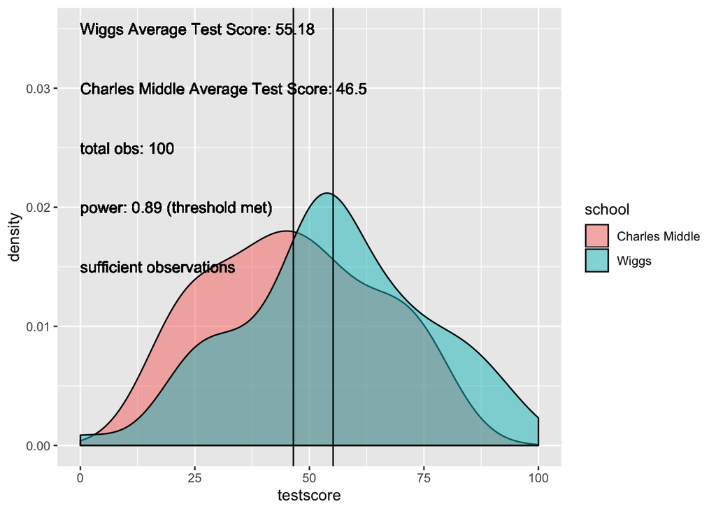

```r
experiment_progress("SELECT school, testscore FROM (
            SELECT student_id, school, testscore, random() AS exp_order
            FROM econ_621.test_scores
            WHERE gradelevel = 5
            AND school IN ('Wiggs', 'Charles Middle')
            AND academic_year = 2015
            AND subject = 'Math'
            AND testname = 'Benchmark') a
          ORDER BY exp_order
          LIMIT 100")
```

b.)

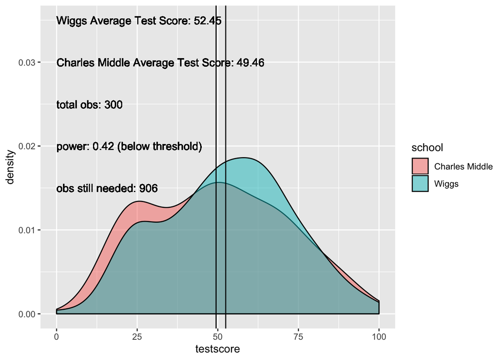

```r
experiment_progress("SELECT school, testscore FROM (
            SELECT student_id, school, testscore, random() AS exp_order
            FROM econ_621.test_scores
            WHERE gradelevel = 5
            AND school IN ('Wiggs', 'Charles Middle')
            AND academic_year = 2015
            AND subject = 'Math'
            AND testname = 'Benchmark') a
          ORDER BY exp_order
          LIMIT 300")
```